# Exercise 3.1:

We will show that equation (6) in the task description is a solution of the diffusion equation by simply inserting it into the equation with constant diffusion coefficient, since the coefficient $D$ is independent of x in the solution.

To show that

$\phi(x,t) = \frac{1}{\sqrt{4\pi Dt}} \int^{+\infty}_{-\infty}dy\,h(y)e^{-\frac{(x-y)^2}{4Dt}}$

is a solution of

$\frac{\partial \phi(x, t)}{\partial t} = D\frac{\partial^2\phi(x,t)}{\partial^2x}$,

we first calculate

$\frac{\partial \phi(x, t)}{\partial t} = -\frac{1}{2} \frac{1}{\sqrt{4\pi Dt}} \frac{1}{t} \int^{+\infty}_{-\infty}dy\,h(y)e^{-\frac{(x-y)^2}{4Dt}} + \frac{1}{\sqrt{4\pi Dt}} \frac{1}{t^2}\int^{+\infty}_{-\infty}dy\,h(y) \, \frac{(x-y)^2}{4D}e^{-\frac{(x-y)^2}{4Dt}} = \frac{1}{\sqrt{4\pi Dt}}(\frac{1}{t^{2}} \int^{+\infty}_{-\infty}dy\,h(y)\,\frac{(x-y)^2}{4D}e^{-\frac{(x-y)^2}{4Dt}} - \frac{1}{2t} \int^{+\infty}_{-\infty}dy\,h(y)e^{-\frac{(x-y)^2}{4Dt}})$.

Then we find

$\frac{\partial\phi(x,t)}{\partial x} = \frac{1}{\sqrt{4\pi Dt}} (-\frac{1}{4Dt}) \int^{+\infty}_{-\infty}dy\,h(y)\,(2x-2y)e^{-\frac{(x-y)^2}{4Dt}}$

$\implies \frac{\partial^2 \phi(x,t)}{\partial^2 x} = \frac{1}{\sqrt{4\pi Dt}}\frac{1}{4Dt}(-\int^{+\infty}_{-\infty}dy\,h(y)\,2e^{-\frac{(x-y)^2}{4Dt}} + \int^{+\infty}_{-\infty}dy\,h(y)\,\frac{(2x-2y)^2}{4Dt}e^{-\frac{(x-y)^2}{4Dt}}) = \frac{1}{D\sqrt{4\pi Dt}}(\frac{1}{t^{2}} \int^{+\infty}_{-\infty}dy\,h(y)\,\frac{(x-y)^2}{4D}e^{-\frac{(x-y)^2}{4Dt}} - \frac{1}{2t} \int^{+\infty}_{-\infty}dy\,h(y)e^{-\frac{(x-y)^2}{4Dt}})$.

It is apparent that the expression (6) is a solution of the equation:

$\implies \frac{\partial \phi(x, t)}{\partial t} = D\frac{\partial^2\phi(x,t)}{\partial^2x}$ $$\tag*{$\blacksquare$}$$

By letting $t \longrightarrow 0$ in Eq. (6) it becomes apparent that the distribution $\phi (x,t)$ becomes narrower. It reduces to a very sharp line (quite like Dirac's Delta) around x = y. Therefore, one may conclude that $h(y)$ represents the initial distribution of the particles.

This solution (6) of the diffusion equation can also be found by applying a Fourier transform to the diffusion equation. By finding the solution this way, it becomes apparent from the beginning of the calculations that the function $h$ represents the initial distribution of the particles. See Peter Lindqvist's detailed solution of the Heat Equation for full details of this method<sup>1</sup>

[Heat Eqn](https://wiki.math.ntnu.no/_media/tma4120/2019h/heat2018.pdf)[<sup>1</sup>]

# Exercise 3.2:

The probability of finding a particle in position $x$ in a potential landscape $V(x)$ is given by $P(x) = Ze^{-\beta V(x)}$, where $Z$ is the canonical partition function of the system and $\beta = (k_B T)^{-1}$.

During a random walk the probability of a particle moving in the positive direction, staying put or moving in the negative direction is, respectively, $\{p^{+}, p^{0}, p^{-}\}$. Normalization dictates that their combined sum should equal one. This means the probabilities must satisfy the equation

\begin{equation}\label{eq1}\tag{1} p^{+} + p^{0} + p^{-} = 1. \end{equation}

We assume that each of the probabilities are proportional to $P(x)$ and that the proportionality constant, $C$, is equal for all steps. If the position before a random walk step is $x_0$ we get

\begin{equation} \begin{aligned} p^{+} & =CP(x_0+1),\\ p^{0} & =CP(x_0),\\ p^{-} & =CP(x_0-1). \label{eq2} \end{aligned} \end{equation}

By putting these expressions into equation \eqref{eq1} we find the constant

\begin{equation}\label{eq3} C=\frac{1}{P(x_0+1)+P(x_0)+P(x_0-1)}, \end{equation}

and the desired probabilities

\begin{equation} \begin{aligned} p^{+} &=\frac{P(x_0+1)}{P(x_0+1)+P(x_0)+P(x_0-1)} = \frac{1}{1+e^{-\beta [V(x_0-1)-V(x_0+1)]}+e^{-\beta [V(x_0)-V(x_0+1)]}}, \\ p^{0} &=\frac{P(x_0)}{P(x_0+1)+P(x_0)+P(x_0-1)} = \frac{1}{1+e^{-\beta [V(x_0-1)-V(x_0)]}+e^{-\beta [V(x_0+1)-V(x_0)]}}, \\ p^{-} &=\frac{P(x_0-1)}{P(x_0+1)+P(x_0)+P(x_0-1)} = \frac{1}{1+e^{-\beta [V(x_0+1)-V(x_0-1)]}+e^{-\beta [V(x_0)-V(x_0-1)]}}. \label{eq4} \end{aligned} \end{equation}$$\tag*{$\blacksquare$}$$

# Exercise 3.3:

With the condition

$k_B T \gg \left|V(x+1)-V(x) \right| = \left|\Delta V(x)\right| \implies \beta \left|\Delta V(x) \right| \ll 1,$

all the exponential terms will reduce to one in the first order series expansion of $\exp(x)$; $e^{-\beta \left|\Delta V(x) \right|} \approx e^{\beta \left| \Delta V(x) \right|} \approx 1$. Since the condition must hold for any $x$, the difference in potential, $\left| \Delta V(x) \right|$, represents a difference for an arbitrary position $x$. By inserting $\left| \Delta V(x) \right|$ in the probabilities found in task 3.2 and taking the absolute value we get

\begin{equation}\label{eq5}\tag{2} p^{+} = \frac{1}{1+e^{2 \beta \left| \Delta V(x) \right|} + e^{\beta \left| \Delta V(x) \right|}} \approx \frac{1}{3}, \end{equation}\begin{equation}\label{eq6}\tag{3} p^{0} = \frac{1}{1+e^{\beta \left| \Delta V(x) \right|} + e^{-\beta \left| \Delta V(x) \right|}} \approx \frac{1}{3}, \end{equation}\begin{equation}\label{eq7}\tag{4} p^{-} = \frac{1}{1+e^{-2 \beta \left| \Delta V(x) \right|} + e^{-\beta \left| \Delta V(x) \right|}} \approx \frac{1}{3}. \end{equation}

This seams rational since the potential is insignificant in relation to the thermal energy with the mentioned condition and therefore the particles must have equal probabilities to either stay put, move to left or to the right.

The other condition states $k_B T \ll \left|V(x+1)-V(x) \right| = \left|\Delta V(x)\right|$. From this we obatin $\beta \left|\Delta V(x) \right| \gg 1 \implies e^{\beta \left| \Delta V(x) \right|} \approx \infty,$ and for the negative case $ -\beta \left|\Delta V(x) \right| \ll 1 \implies e^{-\beta \left| \Delta V(x) \right|} \approx 0$.

With the same expressions for the probabilities as in equation \eqref{eq5}, \eqref{eq6} and \eqref{eq7} it becomes evident that $p^{+} \approx p^{0} \approx 0$ and

\begin{equation} p^{-} = \frac{1}{1+e^{-2 \beta \left| \Delta V(x) \right|} + e^{-\beta \left| \Delta V(x) \right|}} \approx 1. \end{equation}

If the terms in the condition were arranged the opposite way, $k_B T \ll \left|V(x)-V(x+1) \right|$, the probability $p^{+}$ would instead go towards one and $p^{0} \approx p^{-} \approx 0$.

This shows that in the first case the potential is negligible, and in the second the thermal energy is neglible.

These approximations show that if the ratio between the potential and the thermal energy is high the thermal energy makes a negligible impact on the result compared to the potential energy. The energy scale of the potential energy is much larger than that of the thermal energy. Similarly, the potential energy makes a negligible impact on the results when the ratio is small. We shall deal with this ratio, $\beta k$, later.

# Programming exercise 4:

```python
import numpy as np
from scipy.stats import norm
import matplotlib.pyplot as plt
from math import e
import random as rand
from numba import jit

@jit(nopython=True)
def p_plus(x_0, V, beta_k):
    '''
    Probability of random walk step to the right.
    '''
    return 1/(1+e**(-beta_k*(V(x_0-1)-V(x_0+1)))+e**(-beta_k*(V(x_0)-V(x_0+1))))

@jit(nopython=True)
def p_zero(x_0, V, beta_k):
    '''
    Probability of staying put during random walk simulation.
    '''
    return 1/(1+e**(-beta_k*(V(x_0-1)-V(x_0)))+e**(-beta_k*(V(x_0+1)-V(x_0))))

@jit(nopython=True)
def p_minus(x_0, V, beta_k):
    '''
    Probability of random walk step to the left.
    '''
    return 1/(1+e**(-beta_k*(V(x_0+1)-V(x_0-1)))+e**(-beta_k*(V(x_0)-V(x_0-1))))

#Constants used in exercise 4
time_steps = 200
amount_of_particles = 10000
beta_k = [0.01, 1, 100]
step_length = 1
initial = np.zeros((amount_of_particles,), dtype=np.int64)

@jit(nopython=True)
def get_result(V, betaAndK, init):
    '''
    Returns an array of the particles after being influenced by the potential V and the ratio BetaK.
    Randomly decided if the particles move left, right or stay put.
    '''
    new_array = init.copy()
    for step in range(time_steps):
        for position in range(len(init)):
            p = np.random.uniform(0,1)
            if p <= p_minus(new_array[position],V, betaAndK):
                new_array[position] -= step_length
            elif p > (1-p_plus(new_array[position],V, betaAndK)):
                new_array[position] += step_length
    return new_array

@jit(nopython=True)
def mean(data):
    '''
    Finds the mean of data.
    '''
    sum = 0
    for element in data:
        sum += element
    return sum/len(data)

@jit(nopython=True)
def std(data):
    '''
    Finds the standard deviation of data.
    '''
    sum = 0
    mu = mean(data)
    n = len(data)
    for element in data:
        sum += (element-mu)**2
    return np.sqrt(sum/(n-1))

@jit(nopython=True)
def normal(x,mean,std):
    '''
    Finds the normal distribution.
    '''
    return 1/(std*np.sqrt(2*np.pi)) * np.e**(-1/2 * ((x-mean)/std)**2)


def plot_hist(result1, result2, result3):
    '''
    Histogram plot.
    '''
    x1 = np.arange(min(result1),max(result1),1)
    x2 = np.arange(min(result2),max(result2),1)
    x3 = np.arange(min(result3),max(result3),1)
    x_values = [x1, x2, x3]
    xaxe = "Particle position"
    yaxe = "Intensity"
    titles = [r'$\beta k = 0.01$',r'$\beta k = 1$',r'$\beta k = 100$']
    data = [result1, result2, result3]
    f,a = plt.subplots(1,3, figsize=(15,6))
    a[0].set_ylabel(yaxe, fontsize=20)
    a = a.ravel()
    for idx,ax in enumerate(a):
        ax.hist(data[idx])
        ax.set_title(titles[idx], fontsize=20)
        ax.set_xlabel(xaxe, fontsize=20)
        ax.text(0.5,-0.2, "Mean: " + str(mean(data[idx])) + ", Std: " + str(round(std(data[idx]),3)) , size=15, ha="center",transform=ax.transAxes)
    plt.tight_layout(pad = 2.0)
    plt.show()

def plot_normhist(result1, result2, result3):
    '''
    Plots normalized histogram plot.
    '''
    x1 = np.arange(min(result1),max(result1),1)
    x2 = np.arange(min(result2),max(result2),1)
    x3 = np.arange(min(result3),max(result3),1)
    x_values = [x1, x2, x3]
    xaxe = "Particle position"
    yaxe = "PDF"
    titles = [r'$\beta k = 0.01$',r'$\beta k = 1$',r'$\beta k = 100$']
    data = [result1, result2, result3]
    f,a = plt.subplots(1,3, figsize=(15,6))
    a[0].set_ylabel(yaxe, fontsize=20)
    for idx,ax in enumerate(a):
        ax.hist(data[idx], density = True, label="PDF")
        ax.set_title(titles[idx], fontsize=20)
        ax.set_xlabel(xaxe, fontsize=20)
        ax.text(0.5,-0.2, "Mean: " + str(mean(data[idx])) + ", Std: " + str(round(std(data[idx]),3)) , size=15, ha="center",
         transform=ax.transAxes)
        if (std(data[idx]) != 0):
            ax.plot(x_values[idx], normal(x_values[idx], mean(data[idx]), std(data[idx])))

    plt.tight_layout(pad = 2.0)
    plt.show()
```

## Programming exercise 4.1:

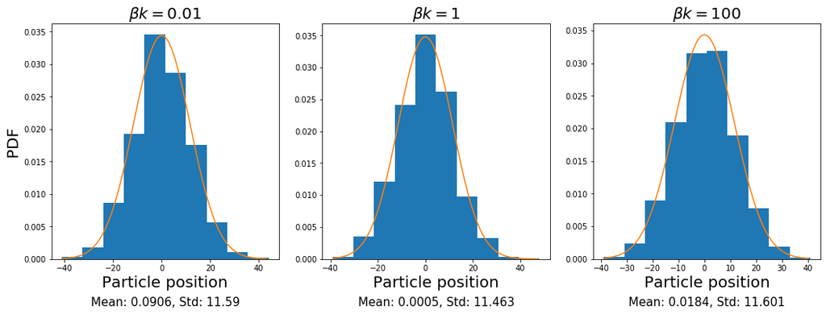

```python
@jit(nopython=True)
def V_1(x):
    '''
    Potential in exercise 4.1
    '''
    k = 1
    return k

result1 = get_result(V_1,beta_k[0], initial)
result2 = get_result(V_1,beta_k[1], initial)
result3 = get_result(V_1,beta_k[2], initial)
plot_normhist(result1, result2, result3)
```

### Discussion 4.1

The figures show that the mean is approximately zero. The resulting distribution of particles is insignificantly influenced by a change in $\beta k$. This is reasonable, since the potential $V_1$ is constant, and therefore does not create a concentration gradient: Random walk in a flat potential corresponds to diffusion with constant diffusion coefficient, as seen in section 2 of the project description. This means that the potential does not change the way the diffusion unfolds. It is also apparent that the mathematical probabilites in 3.2 become $p^+ = p^0 = p^- = \frac {1}{3}$, which further explains why the particle distribution closely resembles a normal distribution.

To quantitatively compare the analytical diffusion equation given by

$\phi(x,t) = \frac{1}{\sqrt{4\pi Dt}} \int^{+\infty}_{-\infty}dy\,h(y)e^{-\frac{(x-y)^2}{4Dt}}$

with our numerical results, we observe that the standard deviation in this expression corresponds to $\sigma = \sqrt{2Dt}$, where $D = \frac{dh^2}{2\Delta t } = 1/3$. Setting $t = 200$, as in the numerical calculations, we obtain $\sigma = 11.547$, which is very close to the numerical standard deviation (see subplots).

## Programming exercise 4.2:

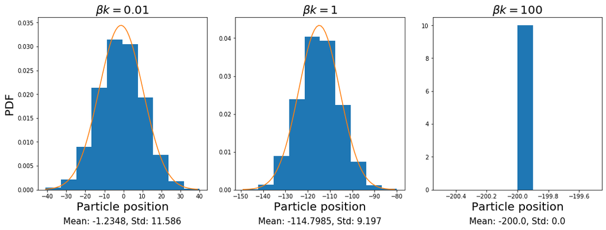

```python
@jit(nopython=True)
def V_2(x):
    '''
    Potential in exercise 4.2
    '''
    return x

result1 = get_result(V_2,beta_k[0], initial)
result2 = get_result(V_2,beta_k[1], initial)
result3 = get_result(V_2,beta_k[2], initial)
plot_normhist(result1, result2, result3)
```

### Discussion 4.2

Potential : $V_2 (x) = x$

The means in the figures can be explained by the fact that the potential $V_2$ is odd, which means that the particles tend towards negative values to minimize their potential energy. Therefore, the particles should be centered around a negative value, as they clearly are. Furthermore, the value of the mean decreases as $\beta k$ increases, which is explained by the fact that the potential becomes increasingly influential to the movement of the particles as the ratio increases. In other words, the thermal energy contributes less and less to the particles' movements.

We see that for $\beta k=0.01$ the distribution clearly resembles a normal distribution with a mean slightly moved from the center $x=0$. The potential still does not significantly influence the diffusion process. As $\beta k$ increases the standard deviation decreases, which means that the distribution gets more concentrated, and the mean increases in the negative direction. In other words, the influence of the potential increases. For $\beta k=100$ the potential is so strong that all the particles are centered in $x=-200$ which is the lowest possible point after $200$ time steps. The thermal energy no longer dictates the diffusion process.

## Programming exercise 4.3:

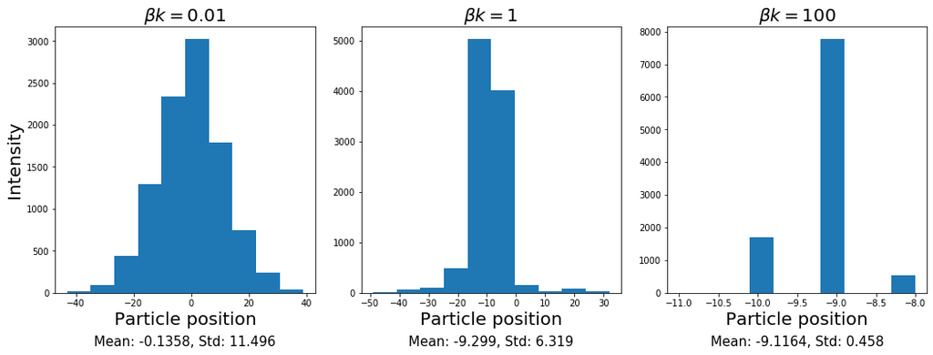

```python
@jit(nopython=True)
def V_3(x):
    '''
    Potential in exercise 4.3
    '''
    return ((x/20)+np.sin(x/5))

result1 = get_result(V_3,beta_k[0], initial)
result2 = get_result(V_3,beta_k[1], initial)
result3 = get_result(V_3,beta_k[2], initial)
plot_hist(result1, result2, result3)
```

### Discussion task 4.3

Potential: $V_3 (x) = \frac{x}{20} + \sin(x/5)$.

The potential $V_3$, as illustrated in the next section, is a harmonic potential, which means that the potential creates several local minimas. Just as earlier, the strength of the potential is too low to greatly affect the particles when $\beta k=0.01$. Therefore, the particle distribution resembles a normal distribution. With $\beta k=100$ all the particles will relax towards the closest "pit" to the center, which is around $x=-9$. The potential is so strong that the particles are kept there. The intermediate ratio, $\beta k=1$, creates a distribution where most of the particles are in the nearest "pit", but some have settled at other positions. If we look closely we can see that there are more particles at $x=20$ than $x=10$ which is becuase there is a local minima at $x=20$.

### Additional task for exercise 4.3

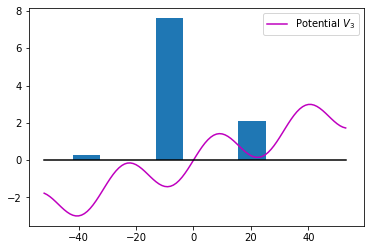

```python
def plot_hist2(result):
    x = np.arange(min(result),max(result),1)
    counts, bins = np.histogram(result)
    plt.hist(bins[:-1], bins, weights=counts/1000)  # scaling down the histogram
    plt.show()

particles = get_result(V_3, beta_k[2], get_result(V_3,beta_k[0], initial))
x = np.arange(min(particles)-10,max(particles),1)
plt.plot(x,V_3(x), color="m", label = r"Potential $V_3$")
plt.plot(x,initial[:len(x)], color='k')
plt.legend()
plot_hist2(particles)
```

### Observations in additional task

The local minimas (the "pits") of the harmonic potential $V_3$ are illustrated alongside the particle distribution.

After $200$ time steps with $\beta k=0.01$ the particles will be distributed as shown in the subplots above. When we start the additional simulation with $200$ time steps and $\beta k=100$, each particle will relax towards its closest local minima. According to the graph, they seem to be be located around $x=-40$, $x=-9$ and $x=20$. This is different from the result in the subplots above, where the particles relaxed to the closest minima to the center only. The difference in the initial distribution when simulating with $\beta k=100$ therefore makes a difference on the result.

## Programming exercise 4.4:

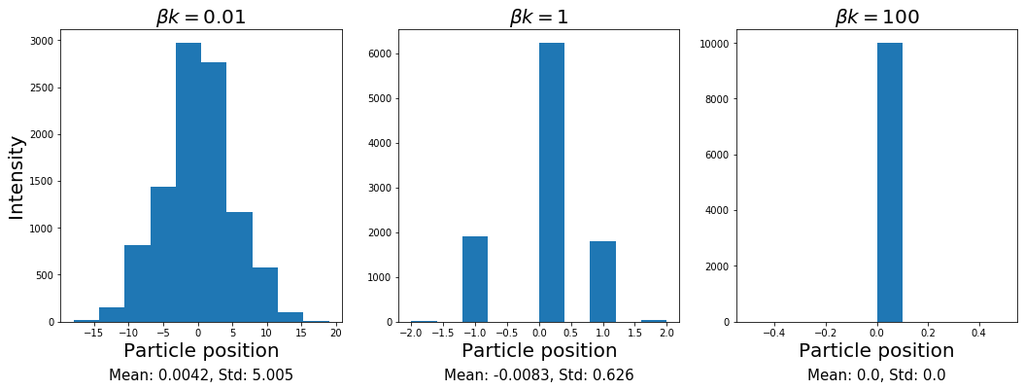

```python
@jit(nopython=True)
def V_4(x):
    '''
    Potential in exercise 4.4
    '''
    return x**2

result1 = get_result(V_4,beta_k[0], initial)
result2 = get_result(V_4,beta_k[1], initial)
result3 = get_result(V_4,beta_k[2], initial)
plot_hist(result1, result2, result3)
```

### Discussion 4.4

Potential: $V_4 (x) = x^2$.

Since the potential $V_4$ is even, a symmetric particle distribution is expected, and the mean should stay approximately equal to zero, since the particles seek to decrease their energy. The potential has a global minima at the center, which means that when the ratio $\beta k$ increases all the particles will be concentrated at the center. These are results we are able to see clearly from the subplots above.

With $\beta k=0.01$ the particle distribution resembles a normal distribution, which can be explained by the fact that the thermal energy is dominant and the potential does not significantly influence the diffusion of particles. When $\beta k$ increases we see the distribution concentrating further around the mean. This, as before, can be explained by the fact that the potential becomes more influential to the diffusion process as the ratio increases. At $\beta k=100$ all the particles are at the minima of the potential. This is in accordance with what we have seen before. With the ratio $\beta k=100$ the potential is fully dominant compared to the thermal effects.

If we compare the standard deviations of the potentials $V_1$ and $V_4$ at the same ratio $\beta k=0.01$, it is clear that the distribution with $V_4$ has a much lower deviation. This simple example shows that the shape of the potential influences the particles' movements. This means that the ratio $\beta k$ cannot $\textit{alone}$ be used to determine whether the thermal energy or the potential energy dominates. However, it is fair to say that it can still be used to gain some knowledge about the diffusion process in a potential, especially in the two limits given in exercise 3.3, as has been shown in the calculations above.

# 5 Random walk in a ratchet potential

```python
#Constants
h = 1   #step length
T_p = 500
delta_t = 1
beta_k = 1000
N_x = 90
N_p = 12*N_x
cycles = 10
jumps = 2*cycles

alpha = 0.8

x_first=-N_x+h
x_last = N_x


@jit(nopython=True)
def V_sawtooth(x, alpha,N_x):
    '''
    Potential V_1(x) from the task description
    '''
    if x <= -(1-alpha)*N_x:
        x += N_x
    elif  alpha*N_x < x:
        x-= N_x
    if (0 < x <= alpha*N_x):
        return x/(alpha*N_x)
    else:
        return -1*(x/((1-alpha)*N_x))


@jit(nopython=True)
def V_constant(x, alpha,N_x):
    '''
    Potential V_2(x) from the task description
    '''
    c = 1
    return c

@jit(nopython=True)
def J(n_plus,n_minus, N_p):
    '''
    Returns the normalized particle current
    '''
    return (n_plus-n_minus)/N_p


def J_avg(current_list):
    '''
    Returns the average of a list
    '''
    average = sum(current_list)/len(current_list)
    return average

@jit(nopython=True)
def p_minus_cycle(x_0, V, alpha, beta_k, N_x):
    '''
    Probability of random walk step to the left.
    Uses periodic boundary conditions
    '''
    value = 0
    x_first = -N_x+h
    x_last = N_x
    if x_0 == x_first:
        value = 1/(1+e**(-beta_k*(V(x_0+1,alpha, N_x)-V(x_last, alpha, N_x)))+e**(-beta_k*(V(x_0,alpha,N_x)-V(x_last,alpha,N_x))))
    elif x_0 == x_last:
        value = 1/(1+e**(-beta_k*(V(x_first,alpha,N_x)-V(x_0-1,alpha,N_x)))+e**(-beta_k*(V(x_0,alpha,N_x)-V(x_0-1,alpha,N_x))))
    else:
        value = 1/(1+e**(-beta_k*(V(x_0+1,alpha,N_x)-V(x_0-1,alpha,N_x)))+e**(-beta_k*(V(x_0,alpha,N_x)-V(x_0-1,alpha,N_x))))
    return value

@jit(nopython=True)
def p_plus_cycle(x_0, V, alpha, beta_k, N_x):
    '''
    Probability of random walk step to the right.
    Uses periodic boundary conditions
    '''
    x_first = -N_x+h
    x_last = N_x
    value = 0
    if x_0 == x_first:
        value = 1/(1+e**(-beta_k*(V(x_last,alpha, N_x)-V(x_0+1,alpha, N_x)))+e**(-beta_k*(V(x_0,alpha, N_x)-V(x_0+1,alpha, N_x))))
    elif x_0 == x_last:
        value = 1/(1+e**(-beta_k*(V(x_0-1,alpha, N_x)-V(x_first,alpha, N_x)))+e**(-beta_k*(V(x_0,alpha, N_x)-V(x_first,alpha, N_x))))
    else:
        value = 1/(1+e**(-beta_k*(V(x_0-1,alpha, N_x)-V(x_0+1,alpha, N_x)))+e**(-beta_k*(V(x_0,alpha, N_x)-V(x_0+1,alpha, N_x))))
    return value

@jit(nopython=True)
def fill_particles():
    '''
    Returns an array of particles evenly distributed along the x-axis
    '''
    particles = np.zeros(N_p,dtype = np.int64)
    number = x_first
    for i in range(1,len(particles)+1):
        particles[i-1] = number
        if i%6 == 0:
            number += 1
    return particles

@jit(nopython=True)
def get_current_per_time_step(V, init, time_steps, alpha, beta_k, N_p, N_x):
    '''
    Returns an array of the normalized particle current per time step
    '''
    x_first = -N_x+h
    x_last = N_x
    current_list_per_time_step = []
    for step in range(time_steps):
        countPos = 0
        countNeg = 0
        for position in range(len(init)):
            p = np.random.uniform(0,1)
            if p <= p_minus_cycle(init[position],V, alpha, beta_k, N_x):
                if init[position] == x_first:
                    init[position] = x_last
                else:
                    init[position] -= 1
                countNeg +=1
            elif p > (1-p_plus_cycle(init[position],V, alpha, beta_k, N_x)):
                if init[position] == x_last:
                    init[position] = x_first
                else:
                    init[position] += 1
                countPos +=1
        current_list_per_time_step.append(J(countPos, countNeg, N_p))
    return current_list_per_time_step

def get_cycle_averaged_current(particles, V1, V2, T_p, jumps, alpha, beta_k, N_p, N_x):
    '''
    Returns an array of the cycle-averaged currents for the specified jumps (jumps = 2*cycles)
    '''
    average_currents = []
    for i in range(jumps):
        if i%2 == 0:
            current_list = []
            currents_per_time_step = get_current_per_time_step(V2,particles,T_p, alpha, beta_k, N_p, N_x)
            current_list = currents_per_time_step
        else:
            currents_per_time_step = get_current_per_time_step(V1,particles,T_p, alpha, beta_k, N_p, N_x)
            current_list += currents_per_time_step
            average_currents.append(round(J_avg(current_list),15)) #Round the currents to as many digits as possible while the array below is visible in it's entirety on the screen.
    return average_currents

def plot_potential():
  '''
  Plots the sawtooth potential
  '''
  x = np.linspace(-N_x,N_x,2*N_x)
  y = np.zeros(len(x))
  for i in range(len(x)):
    y[i] = V_sawtooth(x[i],alpha,N_x)
  plt.plot(x,y)
  plt.xlabel("$x$", fontsize = 20)
  plt.ylabel("$V(x)$",fontsize = 20)
  plt.title(r"$\alpha = $" + str(alpha),fontsize = 20)
  plt.show()

@jit(nopython=True)
def reset_positioning(N_p,N_x):
    '''
    Returns an array of particles which are reset to: half of the particles
    at each of the two x-coordinates which coincide with minima of V_sawtooth.
    '''
    particles = np.zeros(N_p,dtype = np.int64)
    for i in range(len(particles)):
        if i < (len(particles)/2):
            particles[i] = 0
        else:
            particles[i] = N_x
    return particles

def avg_current_vs_time(T_p_values, beta_k, N_p, N_x):
    '''
    Returns an array of average currents, which can be used to plot vs T_p
    '''
    average_currents = []
    particles = reset_positioning(N_p, N_x)
    for T_p in T_p_values:
        average_currents+=get_cycle_averaged_current(particles, V_sawtooth, V_constant, T_p, jumps, alpha, beta_k, N_p, N_x)
    return average_currents

def avg_current_vs_alpha(alpha_values, beta_k, N_p, N_x):
    '''
    Returns an array of average currents, which can be used to plot vs alpha
    '''
    average_currents = []

    for alpha in alpha_values:
        particles = reset_positioning(N_p, N_x)
        average_currents+=get_cycle_averaged_current(particles, V_sawtooth, V_constant, T_p, jumps, alpha, beta_k, N_p, N_x)
    return np.array(average_currents)
```

## 5.1 Programming exercise 5.1

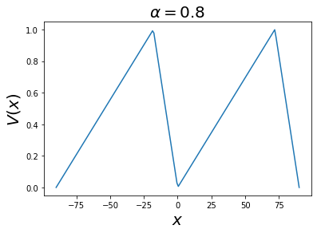

```
[-0.02775, -0.014833333333333, -0.0145, -0.014416666666667, -0.012916666666667, -0.015, -0.014333333333333, -0.015333333333333, -0.013333333333333, -0.01375]
```

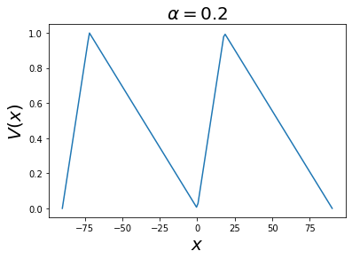

```
[0.027, 0.013833333333333, 0.01225, 0.013166666666667, 0.013583333333333, 0.014, 0.012583333333333, 0.014583333333333, 0.014416666666667, 0.013333333333333]
```

```python
alpha = 0.8
particles = fill_particles()
plot_potential()
print(get_cycle_averaged_current(particles,V_sawtooth, V_constant,T_p, jumps,alpha, beta_k, N_p, N_x))



alpha = 0.2
particles = fill_particles()
plot_potential()
print(get_cycle_averaged_current(particles,V_sawtooth, V_constant,T_p, jumps,alpha, beta_k, N_p,N_x))
```

### Discussion 5.1

- Why we get non-zero currents:

Since we do not have the symmetric case (where $\alpha = 0.5$) there has to be a non-zero current. As we have seen earlier, if the potential is strong enough the particles will always move towards lower potential. In this simulation $\beta k=1000$, which, based on the results in exercise 4, indeed can be said to be strong enough. In that exercise we clearly saw that the particles moved towards the lowest possible potential when $\beta k=100$, which implies that it is fair to expect that the potential dictates the movement of the particles in a greater manner at $\beta k=1000$. As we can see in the illustrations of the potentials, when $\alpha =0.8$ the sawtooth potential is leaning to the right, which means that the bottom is offset to the left. In other words, a particle de-exciting into the sawtooth potential will, on average, travel to the left, since it will move towards the bottom to minimize its potential. When $\alpha = 0.2$ we will have the opposite situation, where the potential leans leftward, resulting in a positive current. We can also see that the absolute values of the current are approximately equal whether $\alpha=0.8$ or $\alpha = 0.2$, due to symmetry.

- Compare $J_{\mathrm{avg}}(0)$ with $J_{\mathrm{avg}}(n)$ for n > 0:

It is apparent that the averaged current during the first cycle is bigger in absolute value than the other cycle-averaged currents. The fact that the particles seek to minimize their potential energy can be used to give a physical interpretaion of this observation. The particles are the furthest from the positions of lowest potential in the beginning, when they are uniformly distributed. In contrast, all the consecutive cycles have an initial position where all the particles are in either one of the minimas. With this initial distribution the constant potential only distributes the particles isotropically with center at the minimas, but not uniformly along the entire x-axis. This is why the averaged current during the first cycle is larger, since, in the first cycle, more particles will relax to the minima, by a bigger amount of steps, than in all the consecutive cycles.

## Programming exercise 5.2

The two x-coordinates which coincide with the minima of $V_1(x)$ must be $x = 0$ and $x = 0 + nN_x$, since it is periodic. The part of $V_1(x)$ which lies within $0 < x \leq \alpha N_x$ is a monotonically increasing function, which means that it's minima is when $x$ is the smallest in the given interval $\Rightarrow$ $x = 0$. The other part of $V_1(x)$ is a monotonically decreasing function, which means that it's minima is at the highest possible $x$ value in the interval $\Rightarrow$ x = 0. However, because of the periodicity of the function, the other minima is at $x = N_x$.

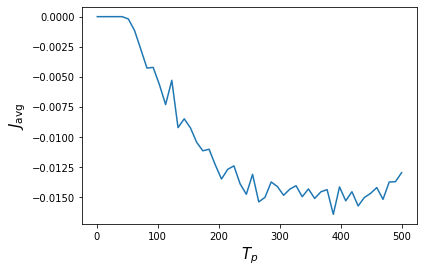

```python
#Constants
N_x = 90
N_p = 40*N_x
alpha = 0.8
jumps = 2
beta_k = 1000


T_p_values = np.linspace(1,500,50)
plt.plot(T_p_values, avg_current_vs_time(T_p_values, beta_k, N_p,N_x))
plt.xlabel(r"$T_p$", fontsize=15)
plt.ylabel(r"$J_{\mathrm{avg}}$", fontsize=15)
plt.show()
```

### Observation and physical interpretation:

From the graph it is apparent that the absolute value of the cycle-averaged current increases as $T_p$ increases. This is because when $T_p$ is small the particles don't have "time" to get distributed to the entire x-axis in the constant potential and therefore the particles move fewer steps before entering the potential minima. We observe that the values of the average current are closely related to the values obtained in exercise 5.1 (except from $J_{avg}(0)$), which seems fair, since the starting position of the particles is approximately the same in both cases.

## Programming exercise 5.3

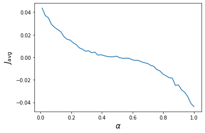

```python
N_x = 90
N_p = 12*N_x
T_p = 500
jumps = 2
beta_k = 1000


alpha_values = np.linspace(0.01,1,50)    #Alpha can't be 0
plt.plot(alpha_values, avg_current_vs_alpha(alpha_values, beta_k, N_p,N_x))
plt.xlabel(r"$\alpha$", fontsize=15)
plt.ylabel(r"$J_{\mathrm{avg}}$", fontsize=15)
plt.show()
```

# 6 Analytical solution

## Programming exercise 6.1

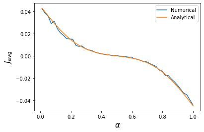

```python
T_p = 500
jumps = 2
beta_k = 1000
h = 1   #step length
N_x=90
N_p = 12*N_x
x_first=-N_x+h
x_last = N_x


from scipy import special

def J_avg_an(alpha,T_p):
  return  N_x/(4*T_p) * (special.erfc( alpha*N_x/2 * np.sqrt(3/T_p) ) - special.erfc( (1-alpha)*N_x/2 * np.sqrt(3/T_p)))

alpha_values = np.linspace(0.01,1,50)   #Alpha can't be zero
plt.plot(alpha_values, avg_current_vs_alpha(alpha_values, beta_k, N_p, N_x), label="Numerical")
plt.plot(alpha_values,J_avg_an(alpha_values,T_p), label="Analytical")
plt.xlabel(r"$\alpha$", fontsize=15)
plt.ylabel(r"$J_{\mathrm{avg}}$", fontsize=15)
plt.legend()
plt.show()
```

### Comparison and comment on the graphs:

From the graph we can see that the analytical and the numerical solutions are strongly coherent. This is in accordance with the assumption that, in the analytical solution, the particles relax towards the potential minima, since we are resetting the positions of the particles to exactly these minimas when running the numerical simulation.

## Programming exercise 6.2

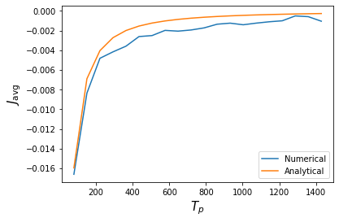

```python
#Constants
h = 1   #step length
N_x = 10
N_p = 3600
alpha = 0.8
jumps = 2
beta_k = 1000
x_first = -N_x+h
x_last = N_x

def J_avg_an(alpha,T_p):
  return  N_x/(4*T_p) * (special.erfc( (alpha*N_x/2) * np.sqrt(3/T_p) ) - special.erfc( ((1-alpha)*N_x/2) * np.sqrt(3/T_p)))

T_p_values2 = np.linspace(80,1500,20, endpoint=False)
plt.plot(T_p_values2, avg_current_vs_time(T_p_values2, beta_k, N_p, N_x), label="Numerical")
plt.plot(T_p_values2,J_avg_an(alpha,T_p_values2), label="Analytical")
plt.xlabel(r"$T_p$", fontsize=15)
plt.ylabel(r"$J_{\mathrm{avg}}$", fontsize=15)
plt.legend()
plt.show()
```

### Comparison and comment on the graphs:

The analytical and numerical solutions seem to be strongly correlated, but seem to deviate from each other for larger values of T_p.

The shape of the graph in the two endpoints $T_p = 80$ and $T_p = 1500$ can be explained by the two following effects. Firstly, when $T_p$ increases, more particles will have "time" to be distributed around the x-axis in the constant potential. This leads to a higher averaged current since a larger amount of particles have to move more steps to relax to the potential minima. This phenomenon was described in task 5.2.

Secondly, as described earlier, $\beta k$ is so large that we can assume that for every time step in the sawtooth potential all the particles will move towards one of the minimas. With $N_x=10$, the maximum amount of time steps needed to move each particle to one of the minimas is $8$, because $\alpha =0.8$. Hereafter, each particle will stay still, and therefore not contribute to a larger $J_{\mathrm{avg}}$. Since we continue increasing $T_p$, the divisor in $J_{\mathrm{avg}}$ increases. This causes the absolute value of the average current to slowly decrease as $T_p$ increases.

Because the diffusion process distributes the particles very slowly around the center (the standard deviation increases slowly), the second effect will be dominant when $T_p$ is large, that is when $T_p > N_x$. The average current therefore decreases, and goes towards zero. This is in accordance with both the numerical and the analytical graphs.

The minima of $J_{\mathrm{avg}}$ could be found numericallly for each case of $N_x$, but we can clearly see that that the average current reaches it's maximum absolute value at some point after $T_p = N_x$. The reason why the graphs only increase in the plot is that $J_{\mathrm{avg}}$ reaches its minima before the interval $[80,1500]$, where the graphs are plotted. With a higher value for $N_x$ the minima exists at a higher $T_p$, for example at $T_p \approx 300$ when $N_x = 90$, as we can see in task 5.2.

See 6.4 for a discussion about the deviation between the numerical and analytical results.

## Programming exercise 6.3

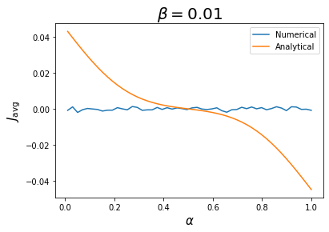

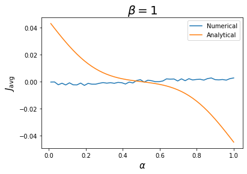

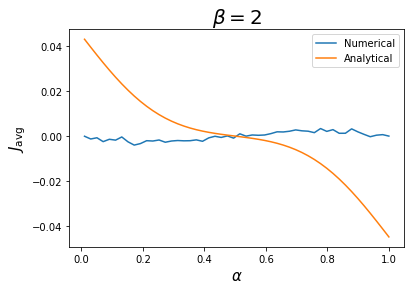

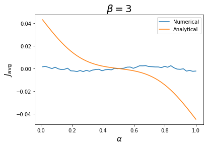

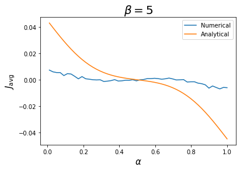

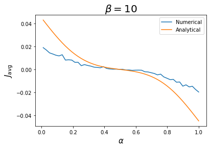

```python
h = 1   #step length
N_x=90
x_first=-N_x+h
x_last = N_x
N_p = 12*N_x
T_p = 500

jumps = 2

beta_and_k = [0.01, 1, 2, 3, 5, 10]

alpha_values = np.linspace(0.01,1,50)    #Alpha can't be zero
for i in range(len(beta_and_k)):
    plt.plot(alpha_values, avg_current_vs_alpha(alpha_values, beta_and_k[i], N_p, N_x), label="Numerical")
    plt.plot(alpha_values, J_avg_an(alpha_values,T_p), label="Analytical")
    plt.xlabel(r"$\alpha$", fontsize=15)
    plt.ylabel(r"$J_{\mathrm{avg}}$", fontsize=15)
    plt.title(r"$\beta = $" + str(beta_and_k[i]),fontsize = 20)
    plt.legend()
    plt.show()
```

### Comparison and comment on the graphs:

As expected, the numerical value of $J_{\mathrm{avg}}$ looks almost flat when $\beta k$ is small. This is because the thermal energy is dominant in this situation and the diffusion process wil go on unaffected with equal probabilities to each of the directions, and therefore create an approximately zero average current.

As $\beta k$ increases, the analytical and numerical graphs resemble each other more and more. The cohersion between the two is expected to become even greater should $\beta k$ be further increased. We can also see that the analytic solution is not influenced by the thermal energy, something we will discuss in the next section.

## Exercise 6.4

In section 6 in the task description, the following is stated:

> "*When the particles find themselves in the sawtooth-shaped potential $V_1(x)$, they will relax towards the potential minima. Hence, as the particles are excited to the second energy level defined by $V_2(x)$, they start out localized at positions $x_n = nN_x$, $n ∈ Z$."*

In other words, it is assumed that the particles in the sawtooth-shaped potential $V_1$ will only be influenced by the strength of the potential, and not by the thermal energy. The thermal energy is completely neglected in the analytical argument. This assumption does not hold under the circumstance where $\beta k << 1$. However, it holds when $\beta k >> 1$, which is why the numerical values fit the theoretical values better for larger values of $\beta k$, as is apparent from 6.3.

As we saw in 6.2, the analytical $J_{\mathrm{avg}}$ diverges from the numerical value when $T_p$ is large compared to $N_x$. This can be attributed to the fact that the analytical argument assumes that the particles contributing to the current only move a maximum length of $N_x$, i.e. to either of the two minimas closest to the starting position. Although this is not explicitly stated in the "analytical argument", it is obvious from the mathematical expression for the average current

$J_{\mathrm{Avg}} = \frac{N_x}{2T_p}\sqrt{\frac{3}{4\pi T_p}}(\int^{+\infty}_{\alpha N_x}dx\,e^{-\frac{3x^2}{4T_p}} - \int^{-(1-\alpha)N_x}_{-\infty}dx\,e^{-\frac{3x^2}{4T_p}}) =\frac{N_x}{2T_p}(n^+ - n^-)$,

where the difference between $n^+$ and $n^-$ is multiplied by $N_x$. The assumption that the particles only move one minima to either side does, however, not hold when $T_p$ is large compared to $N_x$. This is because the particles have more time to diffuse in the constant potential which (in the numerical case) results in some particles diffusing past the neighbouring "valleys", thus contributing to the positive/negative current with $nN_x$, where $n > 1$ (neglecting thermal energy). This explains why the numerical $J_{\mathrm{avg}}$ is greater in absolute value than the analytical for large $T_p$ relative to $N_x$.

To summarize, the analytical solution includes implicit assumptions that $\beta k$ is large (the thermal energy is negligible) and that $T_p$ is not large compared to $N_x$.